# Lecture 8 - Comparing variances

Author: Matthew J. Cossley

Last update: 20 February, 2022

```r
library(data.table)
library(ggplot2)

rm(list=ls())
```

## Comparing the variance of two Normal populations

Let $X \sim \mathcal{N}(\mu_X, \sigma_X)$ and $Y \sim \mathcal{N}(\mu_Y, \sigma_Y)$.

Test the hypothesis that $\sigma^2_X \neq \sigma^2_Y$.

##### step 1

$\begin{align} & H_0: \sigma^2_X = \sigma^2_Y \\ & H_1: \sigma^2_X \neq \sigma^2_Y \\ \end{align}$

We need to restate these hypotheses in a form that allows us to find and use a friendly test statistic.

How about the usual (so far)?

$\begin{align} & H_0: \sigma^2_X - \sigma^2_Y = 0 \\ & H_1: \sigma^2_X - \sigma^2_Y \neq 0 \\ \end{align}$

If you thought that, then good job! However, that turns out to not be what’s used. Instead, we will look at the ratio of variances.

$\begin{align} & H_0: \frac{\sigma^2_X}{\sigma^2_Y} = 1 \\ & H_1: \frac{\sigma^2_X}{\sigma^2_Y} \neq 1 \\ \end{align}$

##### step 2

$\alpha = 0.05$

##### step 3

$\begin{align} \widehat{\frac{\sigma^2_X}{\sigma^2_Y}} = \frac{s^2_X}{s^2_Y} \\ \widehat{\frac{\sigma^2_X}{\sigma^2_Y}} \sim ??? \\ \end{align}$

##### step 3 detour

How is $\widehat{\frac{\sigma^2_X}{\sigma^2_Y}}$ distributed? Lets try to answer this question by simulating many experiments, and estimating the distribution of $\widehat{\frac{\sigma^2_X}{\sigma^2_Y}}$ with a histogram.

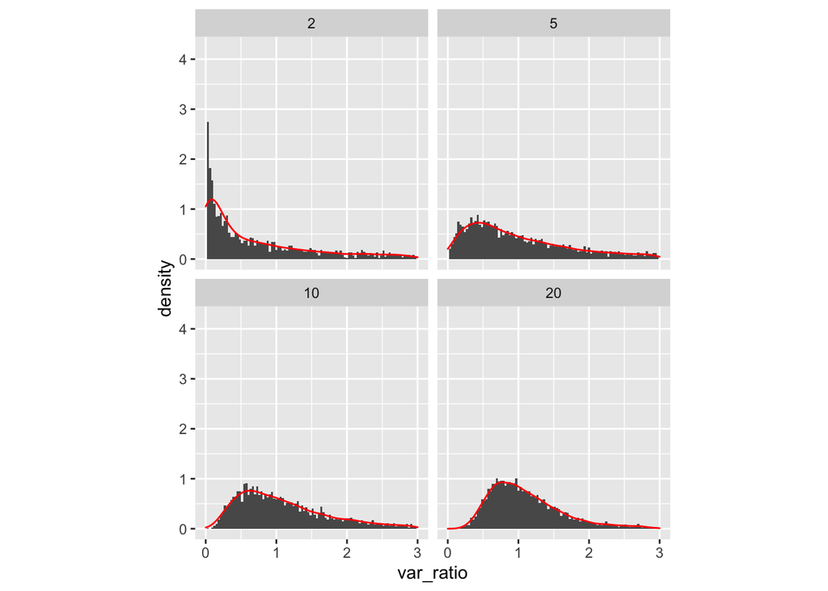

```r
muX <- 0
varX <- 5
sigmaX <- sqrt(varX)

muY <- 0
varY <- 5
sigmaY <- sqrt(varY)

n <- c(2,5,10,20) ## the sample sizes per experiment to explore
d_rec <- list()
for(j in n) {
  for(i in 1:5000) { ## the number of experiments to perform
    x <- rnorm(j, muX, sigmaX)
    y <- rnorm(j, muY, sigmaY)
    var_ratio <- var(x) / var(y)
    d_rec[[i + j*1000]] <- data.table(exp=i, n=j, var_ratio)
  }
}

d <- rbindlist(d_rec)

## var_ratio = varx / vary is definitely not Normally distributed
ggplot(d, aes(var_ratio)) +
  xlim(0,3) +
  geom_histogram(aes(y=..density..), bins=100) +
  geom_density(colour='red') +
  facet_wrap(~n) +
  theme(aspect.ratio = 1)
```

It’s pretty clear that $\widehat{\frac{\sigma^2_X}{\sigma^2_Y}}$ is not normally distributed. It turns out, if $X \sim N(\mu_X,\sigma_X)$, and $Y \sim N(\mu_Y,\sigma_Y)$, and $X$ and $Y$ are independent, then an $F(df_X,df_Y)$ distribution with degrees of freedom $df_X=n_X-1$, $df_Y=n_Y-1$ is a nice model for the sampling distribution of $\widehat{\frac{\sigma^2_X}{\sigma^2_Y}}$.

Here is what an F-distribution looks like.

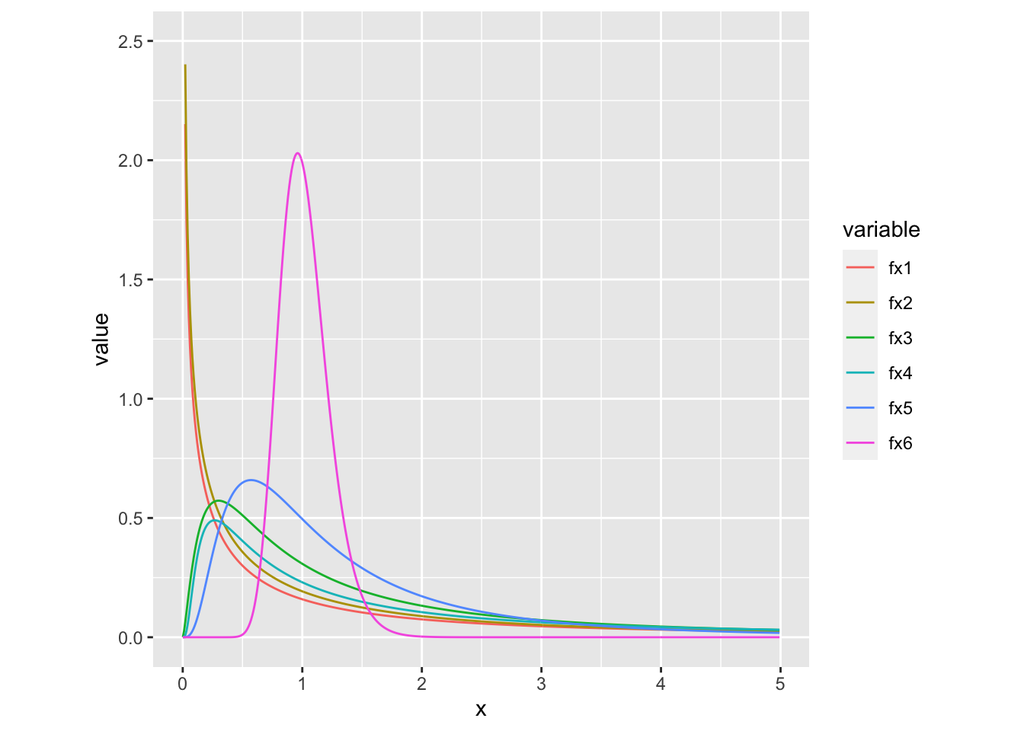

```r
x <- seq(0.001, 5, 0.01)
fx1 <- df(x, 1, 1)
fx2 <- df(x, 1, 2)
fx3 <- df(x, 5, 2)
fx4 <- df(x, 10, 1)
fx5 <- df(x, 10, 5)
fx6 <- df(x, 100, 100)

d <- data.table(x, fx1, fx2, fx3, fx4, fx5, fx6)
dd <- melt(d, id.vars='x')

ggplot(dd, aes(x=x, y=value, colour=variable)) +
  geom_line() +
  ylim(0,2.5) +
  theme(aspect.ratio = 1)
```

To the casual eye, the F and Chisq don’t appear all that different. (1) If you look closely (as in, think very carefully about the properties of each distribution) we will find important differences. (2) They actually aren’t all that different. In fact, Normal, Chisq, and t distributions are all very closely related. You can google it and see for yourself.